```python
import numpy as np
import matplotlib.pyplot as plt
import seaborn as sns

COLOR_PALETTE = ['#648FFF', '#785EF0', '#DC267F', '#FE6100', '#FFB000']
```

# Strong Coexistence

In general we can think of predator prey systems as a series of groups seeking their isoclines. Each group will follow their gradient until they reach a point where they (at least individually) are stable (their gradient is zero).

If all of the gradients for all the groups point in the same direction this will result in a single, smooth path toward some equilibrium point (which may be extinction). This is the case where all of the isoclines (at least locally) are directly on top of one another.

However the more likely story is that each of the individual isoclines represent a line through space that only intersect at points. Therefore in general when an isocline for one group is hit it will mean the other groups are far from their isoclines. Assuming the gradient for the non-stable groups has a component parallel to the axis of the stable group, their seeking an isocline will result in the "stable" group leaving its isocline.

As the originally "non-stable" groups approach their various isoclines their gradients will drop and the gradient of the "non-stable" group will generally rise until eventually the isocline of one of the "non-stable" groups is passed and the process repeats but with the stable and non-stable groups switched.

Let's see this in the works in a very very simple example.

```python
def simulate(x, y, cx, cy, sx, sy, dt, N):
    x_arr = [x]
    y_arr = [y]
    for _ in range(N):
        dx = (- cx* y - x) * sx * dt
        dy =  (cy * x - y) * sy * dt
        x += dx
        y += dy
        x_arr.append(x)
        y_arr.append(y)

    xx_iso = np.arange(min(x_arr), max(x_arr) + 0.01, 0.01)
    yx_iso = np.arange(min(x_arr), max(x_arr) + 0.01, 0.01)
    xy_iso = -1/cx * xx_iso
    yy_iso = cy * yx_iso

    x_filter = (xy_iso >= min(y_arr)) & (xy_iso <= max(y_arr))
    y_filter = (yy_iso >= min(y_arr)) & (yy_iso <= max(y_arr))

    plt.figure(figsize=(8, 5))
    sns.lineplot(x=xx_iso[x_filter], y=xy_iso[x_filter], color=COLOR_PALETTE[0], label='x-isocline')
    sns.lineplot(x=yx_iso[y_filter], y=yy_iso[y_filter], color=COLOR_PALETTE[2], label='y-isocline')
    plt.plot(x_arr, y_arr, color=COLOR_PALETTE[4]);
```

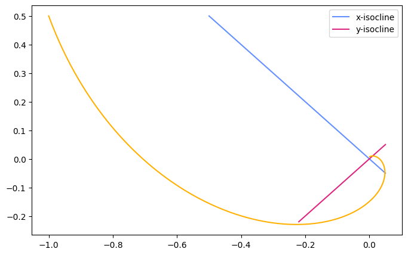

```python
simulate(
    x=-1, y=0.5, cx=1, cy=1, sx=1, sy=1, dt=0.01, N=500
)
```

In this example (and in all the following) we have two groups - one represented by the x-axis and one represented by the y-axis. We also have two isoclines which are just two lines passing through 0,0 and having some slope which we set with $cx$ and $cy$. As $cx\rightarrow \infty$ the x isocline approaches the x-axis. As $cy\rightarrow \infty$ the y isocline approaches the y axis.

The yellow represents our trajectory. Now if a yellow point is on the y isocline, then the gradient of our trajectory with respect to y is 0, if the point is off the y isocline then it will move toward the y isocline with a gradient proportional to $sy$ and the distance between the point's y coordinate and the y isocline along a line parallel to the y-axis (i.e. having the same x coordinate). The same pattern is followed for the x coordinate and the x isocline.

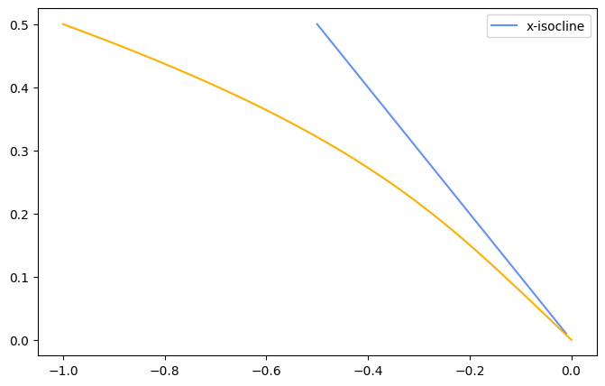

```python
simulate(
    x=-1, y=0.5, cx=1, cy=1, sx=10, sy=1, dt=0.01, N=500
)
```

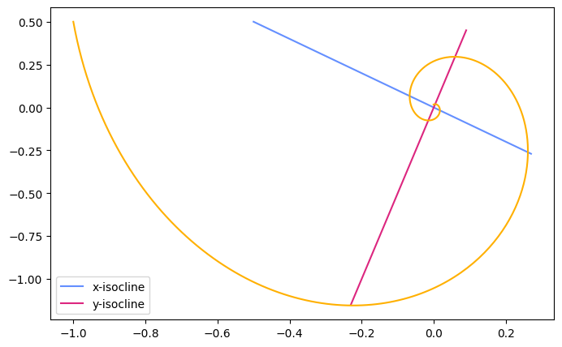

```python
simulate(
    x=-1, y=0.5, cx=1, cy=5, sx=1, sy=1, dt=0.01, N=500
)
```

If instead we increase cy and thereby increase, simulatenously the strength of the y components gradient and its distance before reaching isocline we can see that suddenly the spiral begins to open up and has to make several loops before "reaching home".

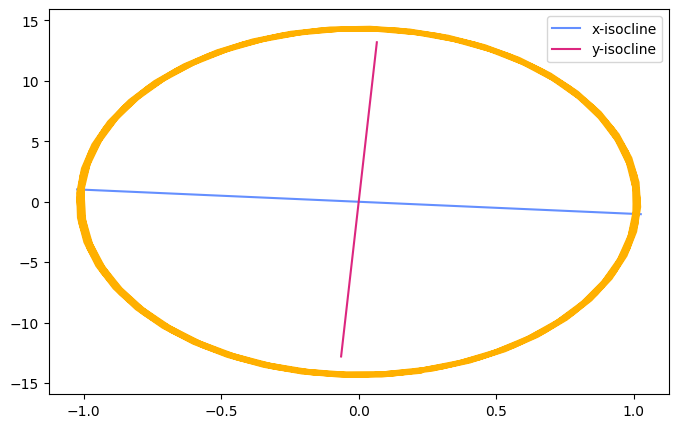

```python
simulate(
    x=-1, y=0.5, cx=1, cy=200, sx=1, sy=1, dt=0.01, N=500
)
```

Continuing along this pattern we can actually open up the spiral so much that it becomes an oscillation.

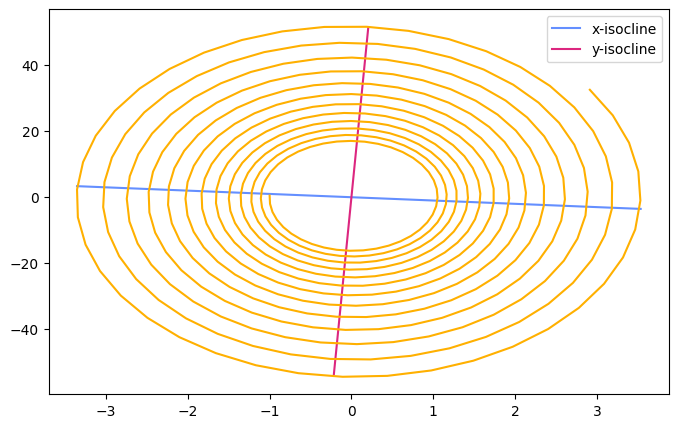

```python
simulate(
    x=-1, y=0.5, cx=1, cy=250, sx=1, sy=1, dt=0.01, N=500
)
```

And then eventually a divergent spiral. Changing cx instead has the exact same effect (albeit in a mirrored sense).

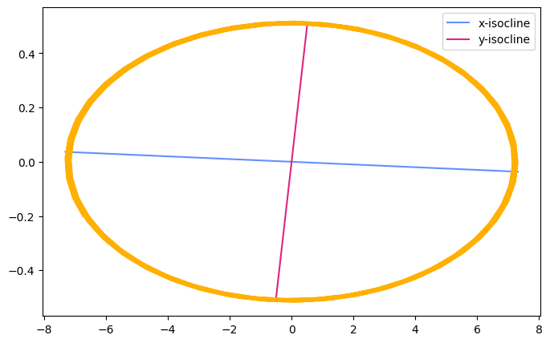

```python
simulate(
    x=-1, y=0.5, cx=200, cy=1, sx=1, sy=1, dt=0.01, N=500
)
```

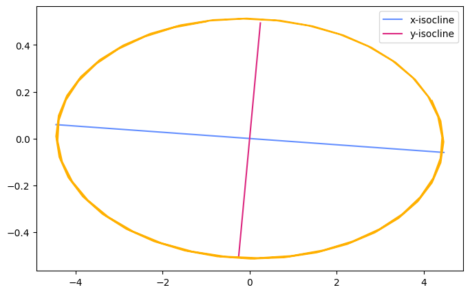

```python
simulate(
    x=-1, y=0.5, cx=75, cy=2, sx=2, sy=1, dt=0.01, N=100
)
```

In general if you mess around with cx, cy, sx, and sy you'll find that if you start with a steady or divergent oscillation that diminishing any one of those parameters enough will turn it into a stable spiral to center.

If we take the analogy of a spring we can see that diminishing cx, cy, sx, or sy is kind of like adding in friction - in this case it is specifically friction to getting to an isocline. As we add in more and more friction (or damping) the likelihood that our system will be stable itself increases.

All to say that stable coexistence exists in the presence of *damping*.